# QIMR_CNV_profiling

[figure not shown]

**This script has been generated by Prakrithi from the *Genomics and Machine Learning Lab*:**

- **Data used below is currently not published or publically available. For more information about the scripts or for the use of this datasets beyond this tutorial please contact uqacause@uq.edu.au**
- **Code and *conda* environments used are available from https://github.com/GMLTestLab/qimr-teaching**
1. Introduction to CNV profiling
2. scRNA-seq Data Loading
3. CopyKAT - Identifying Malignant melanocytes and identifying patient with the tumor
4. InferCNV
5. Consistency of prediction between inferCNV and CopyKAT
6. Analyzing subclones in spatial data using CopyKAT
7. Summary

This is just a tutorial and not a hands-on notebook

# CNV Profiling of Single cell and Spatial RNA sequencing data to identify Tumor cells

### What are CNVs?

A Copy number variation (abbreviated as CNV) refers to an instance in which the number of copies of a specific DNA segment varies among different individuals' genomes. These variations can involve deletions or duplications of segments of the genome and can range from a few kilobases to several megabases in size.

### How are CNVs related to cancer?

- Oncogene Amplification
- Tumor Suppressor Gene Deletion
- Genomic Instability

[figure not shown]

### How can we make use of this DNA profile information for RNA-seq data?

The distinction of malignant from non-malignant cells is a critical step in the follow-up analysis of scRNA-seq tumor datasets. The basic idea to solve such a problem relies on estimating common copy number alterations that characterize transformed cells. The copy number profiles are obtained by considering the gene expression profiles of each cell as a function of the genomic coordinates. The moving average smoothing of the gene expression function is then clustered in malignant and non-malignant cells.

## scRNA-Seq Melanoma dataset

An in-house Melanoma dataset consisting of three samples - One with a malignant tumor and the rest with Dysplastic Nevi (unusual mole that has the potential to turn malignant) has been used to demonstrate the application of CNVs in identifying cancerous cells.

### Load necessary libraries and set working directory

```python
library(Seurat)
setwd("/QRISdata/Q4386/QIMR_workshop_CNV/Mel_3samples")
```

## Load the integrated Melanoma dataset .rds file

Load the seurat object (.rds file converted from anndata object) as Mel_scRNA.  
Mel_scRNA@meta.data$cell_type has the annotated cell type information

```python
Mel_scRNA<-readRDS("Mel_3samples_75pcs.rds")
Mel_scRNA
```

```
An object of class Seurat
3258 features across 10747 samples within 1 assay
Active assay: RNA (3258 features, 0 variable features)
 2 layers present: counts, data
 3 dimensional reductions calculated: pca, pca_harmony, umap
```

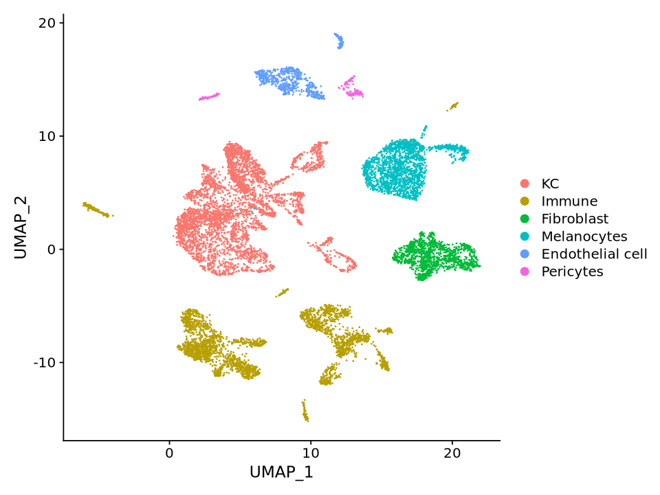

```python
options(repr.plot.width = 8, repr.plot.height = 6)
Idents(Mel_scRNA)<-Mel_scRNA@meta.data$cell_type
DimPlot(Mel_scRNA)
```

**Melanocytes** are the cells from which Melanoma arises. Not all the melanocytes are cancerous. It is necessary to correctly identify the malignant cells, to resolve clonal substructure within the tumor and to identify the patient sample they come from for accurate diagnosis.

## CopyKAT

**CopyKAT (Copy Number Karyotyping of Aneuploid Tumors)** is a tool to identify CNVs from high dimensional RNA-Seq dataset like scRNA-Seq and can be applied to spatial transcriptomics data as well.

It is a reference-free method i.e. It does not require prior cell type annotations defining normal cell profiles.

**Steps involved**

- **step1**: read and filter data. **Input:** Gene - Barcode count matrix
- **step 2**: annotations of genes and ordering them by gene coordinates
- **step 3**: Freeman–Tukey transformation is performed to stabilize variance, followed by polynomial dynamic linear modeling (DLM) to smooth the outliers in the single-cell UMI counts
- **step 4**: detect a subset of diploid cells with high confidence to infer the copy number baseline values of the normal 2N cells. To do this, single cells are pooled into several small hierarchical clusters and estimate the variance of each cluster using a Gaussian mixture model (GMM). The cluster with minimal estimated variance is defined as the ‘confident diploid cells’ by following a strict classification criterion.
- **step 5**: segmentation - Relative gene expression values in single cells are used for MCMC segmentation, and segments are merged by KS testing.
- **step 6**: Prediction: Aneuploid tumor and normal cell clusters are classified using normal cell enrichment and GMM distribution tests. The clonal substructure of tumor cells is delineated by clustering, and subclones are used for downstream analysis.

[figure not shown]

Nature Biotechnology (Nat Biotechnol) ISSN 1546-1696 (online) ISSN 1087-0156 (print)

### copyKAT installation

Uncomment the lines below to install copyKAT and load the library once installed.

```python
#install.packages("devtools")
#library(devtools)
#install_github("navinlabcode/copykat")

library(copykat)
```

## Run CopyKAT

```python
exp.rawdata<-read.csv("MPSs_count_mat.txt",sep="\t")
rownames(exp.rawdata)<-exp.rawdata$GENE
exp.rawdata<-exp.rawdata[,-1]
```

```python
exp.rawdata[1:5,1:5]
```

A data.frame: 5 × 5

|  | MPS13_AAACAAGCAATAGAGAAGAGGCAA.1 <int> | MPS13_AAACAAGCATTCCTTTAGAGGCAA.1 <int> | MPS13_AAACCAATCATCACATAGAGGCAA.1 <int> | MPS13_AAACCAATCATCGATTAGAGGCAA.1 <int> | MPS13_AAACCAATCCCATTGAAGAGGCAA.1 <int> |
| --- | --- | --- | --- | --- | --- |
| SAMD11 | 0 | 0 | 0 | 0 | 0 |
| NOC2L | 0 | 0 | 0 | 0 | 0 |
| KLHL17 | 0 | 0 | 0 | 0 | 0 |
| PLEKHN1 | 1 | 0 | 0 | 0 | 0 |
| PERM1 | 0 | 0 | 0 | 0 | 0 |

```python
copykat.test <- copykat(rawmat=exp.rawdata, id.type="S", ngene.chr=5, win.size=25, KS.cut=0.1, sam.name="test", distance="euclidean", norm.cell.names="",output.seg="FLASE", plot.genes="TRUE", genome="hg20",n.cores=1) #hg20 built-in copkat is the hg38 genome build coordinatess
```

```
[1] "running copykat v1.1.0"
[1] "step1: read and filter data ..."
[1] "14933 genes, 10827 cells in raw data"
[1] "9942 genes past LOW.DR filtering"
[1] "step 2: annotations gene coordinates ..."
[1] "start annotation ..."
[1] "step 3: smoothing data with dlm ..."
[1] "step 4: measuring baselines ..."
number of iterations= 297
number of iterations= 789
number of iterations= 683
number of iterations= 342
number of iterations= 165
number of iterations= 331
[1] "step 5: segmentation..."
[1] "step 6: convert to genomic bins..."
[1] "step 7: adjust baseline ..."
[1] "step 8: final prediction ..."
[1] "step 9: saving results..."
[1] "step 10: ploting heatmap ..."
Time difference of 2.22922 hours
```

### Read CopyKAT predictions

```python
p<-read.csv("test_copykat_prediction.txt", sep="\t",header=TRUE)
head(p)
```

A data.frame: 6 × 2

|  | cell.names <chr> | copykat.pred <chr> |
| --- | --- | --- |
| 1 | MPS13_AAACCAATCATCACATAGAGGCAA.1 | diploid |
| 2 | MPS13_AAACCAATCATCGATTAGAGGCAA.1 | diploid |
| 3 | MPS13_AAACCAATCCCATTGAAGAGGCAA.1 | diploid |
| 4 | MPS13_AAACCAATCGAAATGCAGAGGCAA.1 | diploid |
| 5 | MPS13_AAACCAGGTCACGATTAGAGGCAA.1 | diploid |
| 6 | MPS13_AAACCAGGTGACATTCAGAGGCAA.1 | diploid |

```python
colnames(Mel_scRNA)<-gsub("-1",".1",colnames(Mel_scRNA))
seurat_colnames<-colnames(Mel_scRNA)
rownames(p)<-p$cell.names
p<-p[seurat_colnames,]
# Assuming infercnv_sub_groupings is your DataFrame and seurat_colnames contains the column names from your Seurat object

# Find the order of the BC values in the seurat_colnames
bc_order <- match(p$cell.names, seurat_colnames)

# Reorder the columns of infercnv_sub_groupings based on the order
p_reordered <- p[order(bc_order), ]

# View the reordered DataFrame
dim(p_reordered)
head(p_reordered)
```

1. 10747

2. 2

A data.frame: 6 × 2

|  | cell.names <chr> | copykat.pred <chr> |
| --- | --- | --- |
| MPS13_AAACAAGCAATAGAGAAGAGGCAA.1 | MPS13_AAACAAGCAATAGAGAAGAGGCAA.1 | not.defined |
| MPS13_AAACAAGCATTCCTTTAGAGGCAA.1 | MPS13_AAACAAGCATTCCTTTAGAGGCAA.1 | not.defined |
| MPS13_AAACCAATCATCACATAGAGGCAA.1 | MPS13_AAACCAATCATCACATAGAGGCAA.1 | diploid |
| MPS13_AAACCAATCATCGATTAGAGGCAA.1 | MPS13_AAACCAATCATCGATTAGAGGCAA.1 | diploid |
| MPS13_AAACCAATCCCATTGAAGAGGCAA.1 | MPS13_AAACCAATCCCATTGAAGAGGCAA.1 | diploid |
| MPS13_AAACCAATCCTCAATGAGAGGCAA.1 | MPS13_AAACCAATCCTCAATGAGAGGCAA.1 | not.defined |

## Identify Malignant Tumor cells

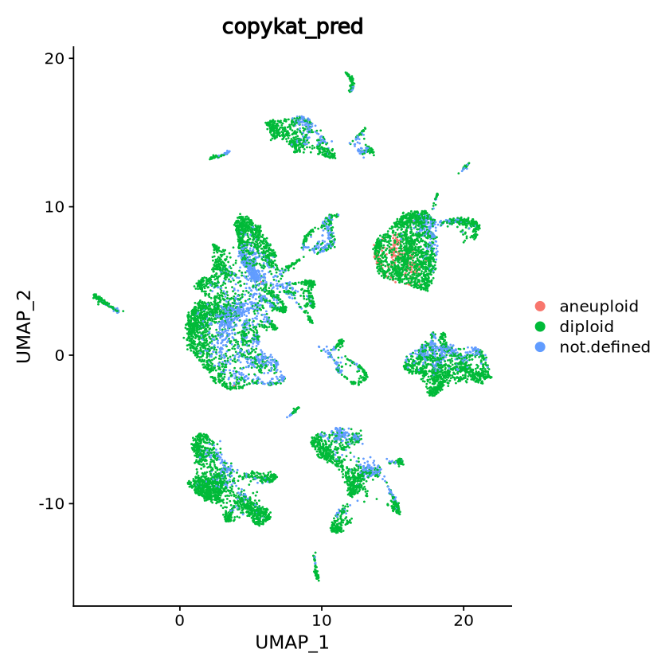

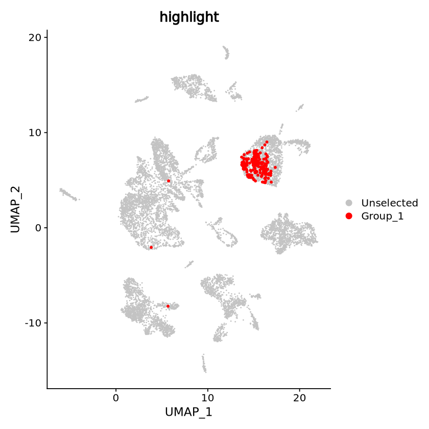

```python
Mel_scRNA@meta.data$copykat_pred<-p$copykat.pred
#Mel_scRNA@meta.data$copykat_aneuploid <- ifelse(Mel_scRNA@meta.data$copykat_pred == "aneuploid", "Aneuploid", "")
aneuploid_cells <- rownames(Mel_scRNA@meta.data)[Mel_scRNA@meta.data$copykat_pred == "aneuploid"]

DimPlot(Mel_scRNA, group.by = "copykat_pred")
DimPlot(Mel_scRNA, group.by = "copykat_pred", cells.highlight = aneuploid_cells, cols.highlight = "red")
```

## Identify the sample with malignant tumor

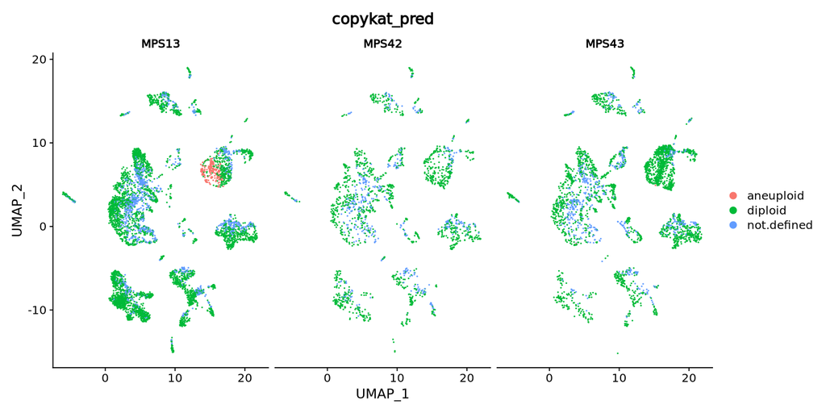

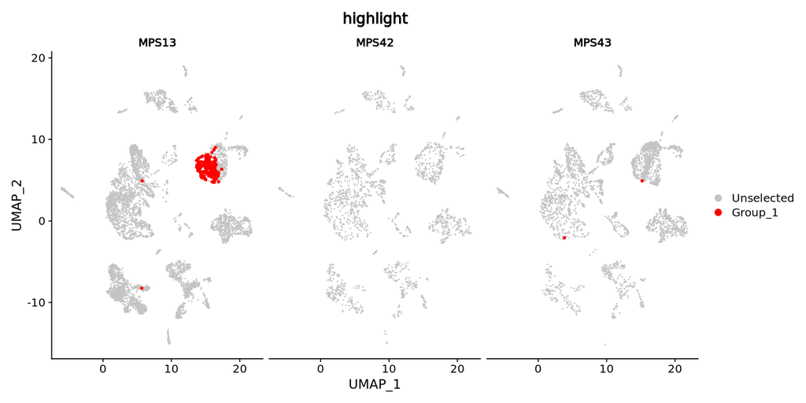

```python
options(repr.plot.width = 12, repr.plot.height = 6)
DimPlot(Mel_scRNA, group.by = "copykat_pred", split.by = "orig.ident")
DimPlot(Mel_scRNA, group.by = "copykat_pred", cells.highlight = aneuploid_cells, cols.highlight = "red", split.by = "orig.ident")
```

## InferCNV

Another tool many used to analyze CNV profiles of tumor cells and to classify subclones

- InferCNV uses a corrected moving average of gene expression data to determine CNV profiles.
- Genes are sorted by absolute genomic position. That is, they are first ordered by chromosome, and then by genomic start position within the chromosome. averaging out the expression of genomically adjacent genes removes gene-specific expression variability and yields profiles that reflect chromosomal copy number variations.
- To further refine the CNV profile of tumor cells, InferCNV constructs the CNV profile of a known normal sample, and then for each gene and each cell, the normal sample is subtracted from the tumor sample to determine the final tumor CNV profile.

More Information at https://github.com/broadinstitute/infercnv/wiki

[figure not shown]

### Data requirements

inferCNV requires:

- a raw counts matrix of single-cell RNA-Seq expression
- an annotations file which indicates which cells are tumor vs. normal.
- a gene/chromosome positions file

Detailed documentation: https://www.bioconductor.org/packages/release/bioc/manuals/infercnv/man/infercnv.pdf

### Installation

```python
if (!require("BiocManager", quietly = TRUE))
    install.packages("BiocManager")
BiocManager::install("infercnv")
```

```python
library(infercnv)
```

### Preparing metadata file containing cell-type information from previously loaded seurat object

```python
options("Mel_scRNA.assay.version" = "v3")
infercnv_meta <- data.frame(V1 = Mel_scRNA@meta.data$cell_type)
rownames(infercnv_meta)<-rownames(Mel_scRNA@meta.data)
head(infercnv_meta)
```

A data.frame: 6 × 1

|  | V1 <chr> |
| --- | --- |
| MPS13_AAACAAGCAATAGAGAAGAGGCAA.1 | KC |
| MPS13_AAACAAGCATTCCTTTAGAGGCAA.1 | KC |
| MPS13_AAACCAATCATCACATAGAGGCAA.1 | KC |
| MPS13_AAACCAATCATCGATTAGAGGCAA.1 | Immune |
| MPS13_AAACCAATCCCATTGAAGAGGCAA.1 | KC |
| MPS13_AAACCAATCCTCAATGAGAGGCAA.1 | KC |

```python
unique(Mel_scRNA@meta.data$Level1_res1)
```

1. KC

2. Immune

3. Fibroblast

4. Melanocytes

5. Endothelial cell

**Levels**:**

1. ''

2. 'Endothelial cell'

3. 'Fibroblast'

4. 'Immune'

5. 'KC'

6. 'Melanocytes'

### Create InferCNV object

You can set the reference 'Normal' cell-types as a list using ref_group_names. Or you could set it to NULL.  
Either way inferCNV identifies aneuploid cells and infers subclones using predicted CNV profiles

```python
infercnv_obj = CreateInfercnvObject(
  raw_counts_matrix=GetAssayData(Mel_scRNA, slot="counts"),
  annotations_file=infercnv_meta,
  delim="\t",
  gene_order_file="/scratch/project/stseq/Prakrithi/skin_atlas/infercnv/hg38_gencode_v27.txt",
  ref_group_names=NULL) #c("KC","Immune","Fibroblast","Endothelial cell"))
```

[output not shown]

### Run InferCNV

```python
out_dir = tempfile()
infercnv_obj_default = infercnv::run(
    infercnv_obj,
    cutoff=1, # cutoff=1 works well for Smart-seq2, and cutoff=0.1 works well for 10x Genomics
    out_dir="infercnv/all/",
    cluster_by_groups=TRUE,
    plot_steps=FALSE,
    denoise=TRUE,
    HMM=FALSE,
    no_prelim_plot=TRUE,
    png_res=60
)
```

```
INFO [2024-05-30 21:48:16] ::process_data:Start
INFO [2024-05-30 21:48:16] Creating output path infercnv/all/
INFO [2024-05-30 21:48:16] Checking for saved results.
INFO [2024-05-30 21:48:16]

	STEP 1: incoming data

INFO [2024-05-30 21:48:17]

	STEP 02: Removing lowly expressed genes

INFO [2024-05-30 21:48:17] ::above_min_mean_expr_cutoff:Start
INFO [2024-05-30 21:48:17] Removing 3003 genes from matrix as below mean expr threshold: 1
INFO [2024-05-30 21:48:17] validating infercnv_obj
INFO [2024-05-30 21:48:17] There are 110 genes and 284 cells remaining in the expr matrix.
INFO [2024-05-30 21:48:17] no genes removed due to min cells/gene filter
INFO [2024-05-30 21:48:17]

	STEP 03: normalization by sequencing depth

INFO [2024-05-30 21:48:17] normalizing counts matrix by depth
INFO [2024-05-30 21:48:17] Computed total sum normalization factor as median libsize: 157.637109
INFO [2024-05-30 21:48:17]

	STEP 04: log transformation of data

INFO [2024-05-30 21:48:17] transforming log2xplus1()
```

```
INFO [2024-05-30 21:48:17]

	STEP 08: removing average of reference data (before smoothing)

INFO [2024-05-30 21:48:17] ::subtract_ref_expr_from_obs:Start inv_log=FALSE, use_bounds=TRUE
INFO [2024-05-30 21:48:17] -no reference cells specified... using mean of all cells as proxy
INFO [2024-05-30 21:48:17] -subtracting expr per gene, use_bounds=TRUE
INFO [2024-05-30 21:48:18]

	STEP 09: apply max centered expression threshold: 3

INFO [2024-05-30 21:48:18] ::process_data:setting max centered expr, threshold set to: +/-:  3
INFO [2024-05-30 21:48:19]

	STEP 10: Smoothing data per cell by chromosome

INFO [2024-05-30 21:48:19] smooth_by_chromosome: chr: chr1
INFO [2024-05-30 21:48:19] smooth_by_chromosome: chr: chr2
INFO [2024-05-30 21:48:19] smooth_by_chromosome: chr: chr3
INFO [2024-05-30 21:48:19] smooth_by_chromosome: chr: chr4
INFO [2024-05-30 21:48:19] smooth_by_chromosome: chr: chr5
INFO [2024-05-30 21:48:19] smooth_by_chromosome: chr: chr6
INFO [2024-05-30 21:48:19] smooth_by_chromosome: chr: chr7
INFO [2024-05-30 21:48:19] smooth_by_chromosome: chr: chr8
INFO [2024-05-30 21:48:19] smooth_by_chromosome: chr: chr9
INFO [2024-05-30 21:48:19] smooth_by_chromosome: chr: chr10
INFO [2024-05-30 21:48:19] smooth_by_chromosome: chr: chr11
INFO [2024-05-30 21:48:19] smooth_by_chromosome: chr: chr12
INFO [2024-05-30 21:48:19] smooth_by_chromosome: chr: chr13
INFO [2024-05-30 21:48:19] smooth_by_chromosome: chr: chr14
INFO [2024-05-30 21:48:19] smooth_by_chromosome: chr: chr15
INFO [2024-05-30 21:48:19] smooth_by_chromosome: chr: chr16
INFO [2024-05-30 21:48:19] smooth_by_chromosome: chr: chr17
INFO [2024-05-30 21:48:19] smooth_by_chromosome: chr: chr18
INFO [2024-05-30 21:48:19] smooth_by_chromosome: chr: chr19
INFO [2024-05-30 21:48:19] smooth_by_chromosome: chr: chr20
INFO [2024-05-30 21:48:19] smooth_by_chromosome: chr: chr21
INFO [2024-05-30 21:48:19] smooth_by_chromosome: chr: chr22
INFO [2024-05-30 21:48:19]

	STEP 11: re-centering data across chromosome after smoothing

INFO [2024-05-30 21:48:19] ::center_smooth across chromosomes per cell
INFO [2024-05-30 21:48:20]

	STEP 12: removing average of reference data (after smoothing)

INFO [2024-05-30 21:48:20] ::subtract_ref_expr_from_obs:Start inv_log=FALSE, use_bounds=TRUE
INFO [2024-05-30 21:48:20] -no reference cells specified... using mean of all cells as proxy
INFO [2024-05-30 21:48:20] -subtracting expr per gene, use_bounds=TRUE
INFO [2024-05-30 21:48:21]

	STEP 14: invert log2(FC) to FC

INFO [2024-05-30 21:48:21] invert_log2(), computing 2^x
INFO [2024-05-30 21:48:21]

	STEP 15: computing tumor subclusters via leiden

INFO [2024-05-30 21:48:21] define_signif_tumor_subclusters(p_val=0.1
INFO [2024-05-30 21:48:21] define_signif_tumor_subclusters(), tumor: 1
INFO [2024-05-30 21:48:21] Setting auto leiden resolution for 1 to 0.0848905
```

[output not shown]

```
INFO [2024-05-30 21:48:21] define_signif_tumor_subclusters(), tumor: 15
INFO [2024-05-30 21:48:21] Setting auto leiden resolution for 15 to 0.266148
```

[output not shown]

```
INFO [2024-05-30 21:48:22] define_signif_tumor_subclusters(), tumor: 19
INFO [2024-05-30 21:48:22] Less cells in group 19 than k_nn setting. Keeping as a single subcluster.
INFO [2024-05-30 21:48:22] define_signif_tumor_subclusters(), tumor: 6
INFO [2024-05-30 21:48:22] Less cells in group 6 than k_nn setting. Keeping as a single subcluster.
INFO [2024-05-30 21:48:22] ::plot_cnv:Start
INFO [2024-05-30 21:48:22] ::plot_cnv:Current data dimensions (r,c)=110,284 Total=31523.9000985466 Min=0.152190361295983 Max=8.0712690249139.
INFO [2024-05-30 21:48:22] ::plot_cnv:Depending on the size of the matrix this may take a moment.
INFO [2024-05-30 21:48:22] plot_cnv(): auto thresholding at: (0.445629 , 1.572547)
INFO [2024-05-30 21:48:22] plot_cnv_observation:Start
INFO [2024-05-30 21:48:22] Observation data size: Cells= 284 Genes= 110
INFO [2024-05-30 21:48:22] clustering observations via method: ward.D
INFO [2024-05-30 21:48:22] Number of cells in group(1) is 48
INFO [2024-05-30 21:48:22] group size being clustered:  48,110
INFO [2024-05-30 21:48:22] Number of cells in group(2) is 40
INFO [2024-05-30 21:48:22] group size being clustered:  40,110
INFO [2024-05-30 21:48:22] Number of cells in group(3) is 35
INFO [2024-05-30 21:48:22] group size being clustered:  35,110
INFO [2024-05-30 21:48:22] Number of cells in group(4) is 27
INFO [2024-05-30 21:48:22] group size being clustered:  27,110
INFO [2024-05-30 21:48:22] Number of cells in group(5) is 26
INFO [2024-05-30 21:48:22] group size being clustered:  26,110
INFO [2024-05-30 21:48:22] Number of cells in group(6) is 22
INFO [2024-05-30 21:48:22] group size being clustered:  22,110
INFO [2024-05-30 21:48:22] Number of cells in group(7) is 14
INFO [2024-05-30 21:48:22] group size being clustered:  14,110
INFO [2024-05-30 21:48:22] Number of cells in group(8) is 37
INFO [2024-05-30 21:48:22] group size being clustered:  37,110
INFO [2024-05-30 21:48:22] Number of cells in group(9) is 18
INFO [2024-05-30 21:48:22] group size being clustered:  18,110
INFO [2024-05-30 21:48:22] Number of cells in group(10) is 1
INFO [2024-05-30 21:48:22] Skipping group: 10, since less than 2 entries
INFO [2024-05-30 21:48:22] Number of cells in group(11) is 8
INFO [2024-05-30 21:48:22] group size being clustered:  8,110
INFO [2024-05-30 21:48:22] Number of cells in group(12) is 8
INFO [2024-05-30 21:48:22] group size being clustered:  8,110
INFO [2024-05-30 21:48:22] plot_cnv_observation:Writing observation groupings/color.
INFO [2024-05-30 21:48:22] plot_cnv_observation:Done writing observation groupings/color.
INFO [2024-05-30 21:48:22] plot_cnv_observation:Writing observation heatmap thresholds.
INFO [2024-05-30 21:48:22] plot_cnv_observation:Done writing observation heatmap thresholds.
INFO [2024-05-30 21:48:22] Colors for breaks:  #00008B,#24249B,#4848AB,#6D6DBC,#9191CC,#B6B6DD,#DADAEE,#FFFFFF,#EEDADA,#DDB6B6,#CC9191,#BC6D6D,#AB4848,#9B2424,#8B0000
```

[output cut: 8 more lines]

```
INFO [2024-05-30 21:48:24]

## Making the final infercnv heatmap ##
INFO [2024-05-30 21:48:24] ::plot_cnv:Start
INFO [2024-05-30 21:48:24] ::plot_cnv:Current data dimensions (r,c)=110,284 Total=31888.9794849007 Min=0.152190361295983 Max=8.0712690249139.
INFO [2024-05-30 21:48:24] ::plot_cnv:Depending on the size of the matrix this may take a moment.
INFO [2024-05-30 21:48:24] plot_cnv(): auto thresholding at: (0.427453 , 1.572547)
INFO [2024-05-30 21:48:24] plot_cnv_observation:Start
INFO [2024-05-30 21:48:24] Observation data size: Cells= 284 Genes= 110
INFO [2024-05-30 21:48:24] plot_cnv_observation:Writing observation groupings/color.
INFO [2024-05-30 21:48:24] plot_cnv_observation:Done writing observation groupings/color.
INFO [2024-05-30 21:48:24] plot_cnv_observation:Writing observation heatmap thresholds.
INFO [2024-05-30 21:48:24] plot_cnv_observation:Done writing observation heatmap thresholds.
INFO [2024-05-30 21:48:24] Colors for breaks:  #00008B,#24249B,#4848AB,#6D6DBC,#9191CC,#B6B6DD,#DADAEE,#FFFFFF,#EEDADA,#DDB6B6,#CC9191,#BC6D6D,#AB4848,#9B2424,#8B0000
INFO [2024-05-30 21:48:24] Quantiles of plotted data range: 0.427453435037248,1.00908771122108,1.00908771122108,1.00908771122108,1.57254656496275
```

[figure not shown]

When you specify reference cell types, they are clustered separately. If not they are still clustered separately but are given cluster numbers

In both cases, the aneuploid cells are subclustered. The diploid cells are excluded in the subcluster-prediction file infercnv_subclusters.observation*groupings.txt. Pick the cells following a prefix 1* in the HeatMap since this is the largest aneuploid cluster (Melanocytes). The other inclusions could be artifacts or false predictions and might need further investigation. They could also be validated by comparing predictions from CopyKAT and choose the cells with consistent aneuploid predictions across both tools.

[figure not shown]

Alternately, you could calculate CNV scores  
**scores=apply(infercnv_obj@expr.data,2,function(x){ sum(x < 0.95 | x > 1.05)/length(x) })**  
and plot the distribution of a gene. If you see a binormal distribution, you could choose the cut-off based on where the first peak drops to choose aneuploid cells.

Example:

[figure not shown]

```python
infercnv_sub_groupings<-read.csv("infercnv/all/infercnv_subclusters.observation_groupings.txt", sep=" ",header=TRUE)
tail(infercnv_sub_groupings)
```

A data.frame: 6 × 4

|  | Dendrogram.Group <int> | Dendrogram.Color <chr> | Annotation.Group <int> | Annotation.Color <chr> |
| --- | --- | --- | --- | --- |
| MPS13_GTTGGATAGGCGATATAGAGGCAA.1 | 1 | #8DD3C7 | 12 | #FFED6F |
| AAACCAGGTAAAGGCCATACGTCA.1 | 1 | #8DD3C7 | 12 | #FFED6F |
| MPS13_TTCCTCCCATTGTGAGAGAGGCAA.1 | 1 | #8DD3C7 | 12 | #FFED6F |
| TGCTTAAGTGCTGCACATACGTCA.1 | 1 | #8DD3C7 | 12 | #FFED6F |
| MPS42_AACCCGGCATTGTGTCACTACTCA.1 | 1 | #8DD3C7 | 12 | #FFED6F |
| CTCATTACAACAGGGAATACGTCA.1 | 1 | #8DD3C7 | 12 | #FFED6F |

infercnv_subclusters.observation_groupings.txt contains the sub-clusters of the Aneuploid cells. 284 cells are predicted aneuploid and are further classified into 12 clusters.

```python
unique(infercnv_sub_groupings$Annotation.Group)
dim(infercnv_sub_groupings)
```

1. 1

2. 2

3. 3

4. 4

5. 5

6. 6

7. 7

8. 8

9. 9

10. 10

11. 11

12. 12

1. 284

2. 4

```python
rownames(infercnv_sub_groupings)<-infercnv_sub_groupings$BC

# Find the order of the BC values in the seurat_colnames
bc_order <- match(rownames(infercnv_sub_groupings), colnames(Mel_scRNA))

# Reorder the columns of infercnv_sub_groupings based on the order
infercnv_sub_groupings_reordered <- infercnv_sub_groupings[order(bc_order), ]

# View the reordered DataFrame
head(infercnv_sub_groupings_reordered)
```

A data.frame: 6 × 4

|  | Dendrogram.Group <int> | Dendrogram.Color <chr> | Annotation.Group <int> | Annotation.Color <chr> |
| --- | --- | --- | --- | --- |
| 1 | 1 | #8DD3C7 | 1 | #8DD3C7 |
| 2 | 1 | #8DD3C7 | 1 | #8DD3C7 |
| 3 | 1 | #8DD3C7 | 1 | #8DD3C7 |
| 4 | 1 | #8DD3C7 | 1 | #8DD3C7 |
| 5 | 1 | #8DD3C7 | 1 | #8DD3C7 |
| 6 | 1 | #8DD3C7 | 1 | #8DD3C7 |

```python
# Create a new column in Mel_scRNA@meta.data with empty values
Mel_scRNA@meta.data$infercnv_pred <- ""

# Get the row names of both data frames
mel_row_names <- rownames(Mel_scRNA@meta.data)
infercnv_row_names <- rownames(infercnv_sub_groupings)

# Find the matching row names
matching_row_names <- intersect(mel_row_names, infercnv_row_names)

# Update the new column with "Aneuploid" for matching rows
Mel_scRNA@meta.data[matching_row_names, "infercnv_pred"] <- "Aneuploid"

# Check the updated meta.data
head(Mel_scRNA@meta.data)
```

A data.frame: 6 × 18

|  | orig.ident <fct> | nCount_RNA <dbl> | nFeature_RNA <dbl> | nFeaturess_RNA_by_counts <dbl> | total_counts <dbl> | total_counts_mt <dbl> | pct_counts_mt <dbl> | leiden <fct> | leiden_res0_25 <fct> | leiden_res0_5 <fct> | leiden_res1 <fct> | Level1 <fct> | Level2 <fct> | Level1_res1 <fct> | Level2_res1 <fct> | copykat_pred <chr> | cell_type <chr> | infercnv_pred <chr> |
| --- | --- | --- | --- | --- | --- | --- | --- | --- | --- | --- | --- | --- | --- | --- | --- | --- | --- | --- |
| MPS13_AAACAAGCAATAGAGAAGAGGCAA.1 | MPS13 | 971 | 594 | 593 | 970 | 7 | 0.7216495 | 6 | 6 | 8 | 13 | KC | KC Cornified | KC | KC Cornified | not.defined | KC |  |
| MPS13_AAACAAGCATTCCTTTAGAGGCAA.1 | MPS13 | 969 | 502 | 502 | 969 | 10 | 1.0319917 | 6 | 6 | 8 | 13 | KC | KC Cornified | KC | KC Cornified | not.defined | KC |  |
| MPS13_AAACCAATCATCACATAGAGGCAA.1 | MPS13 | 1183 | 810 | 808 | 1180 | 22 | 1.8644068 | 9 | 6 | 8 | 12 | KC | KC Differentiating | KC | KC Differentiating | diploid | KC |  |
| MPS13_AAACCAATCATCGATTAGAGGCAA.1 | MPS13 | 1703 | 1303 | 1302 | 1701 | 28 | 1.6460905 | 7 | 2 | 9 | 8 | Immune | T cell | Immune | CD8+ T cell | diploid | Immune |  |
| MPS13_AAACCAATCCCATTGAAGAGGCAA.1 | MPS13 | 3297 | 1792 | 1792 | 3297 | 33 | 1.0009099 | 9 | 6 | 8 | 12 | KC | KC Differentiating | KC | KC Differentiating | diploid | KC |  |
| MPS13_AAACCAATCCTCAATGAGAGGCAA.1 | MPS13 | 667 | 557 | 556 | 666 | 0 | 0.0000000 | 11 | 8 | 11 | 16 | KC | KC stem/hair/stress | KC | KC stem/hair/stress | not.defined | KC |  |

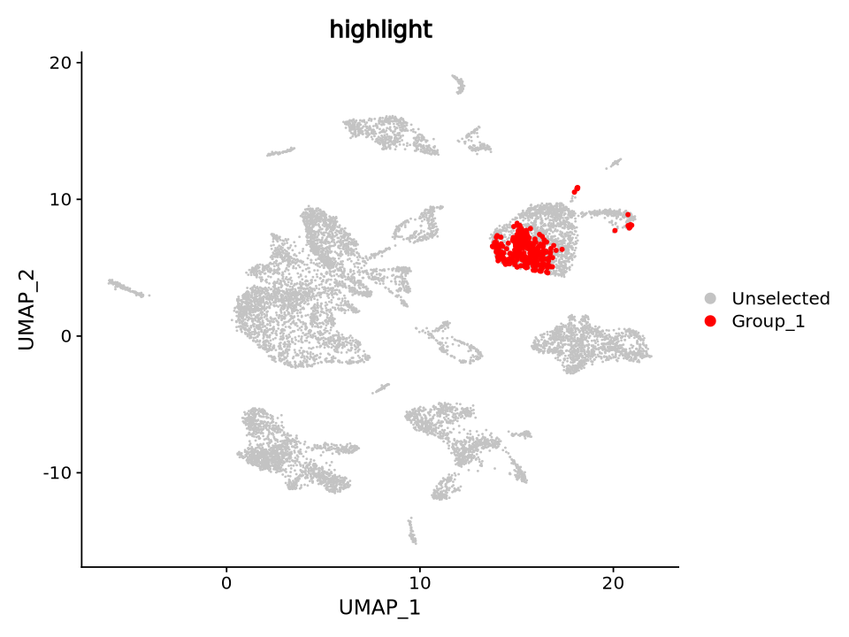

```python
infercnv_aneuploid_cells <- rownames(Mel_scRNA@meta.data)[Mel_scRNA@meta.data$infercnv_pred == "Aneuploid"]
DimPlot(Mel_scRNA, group.by = "infercnv_pred", cells.highlight = infercnv_aneuploid_cells, cols.highlight = "red")
```

## Consistency of prediction between inferCNV and CopyKAT

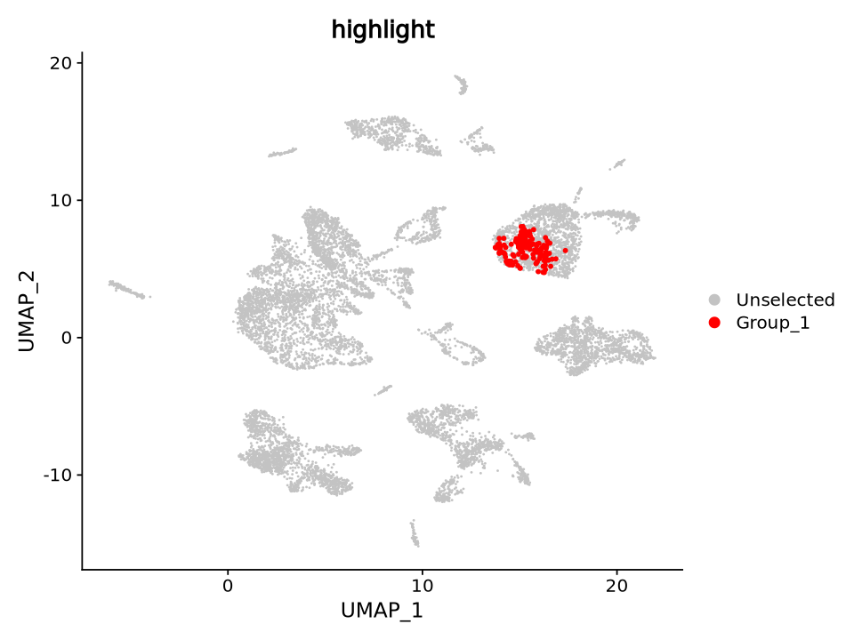

```python
# Create a new column in Mel_scRNA@meta.data with empty values
Mel_scRNA@meta.data$copykat_infercnv_consistent <- ""

# Update the new column with "Aneuploid" where both conditions are met
Mel_scRNA@meta.data$copykat_infercnv_consistent[Mel_scRNA@meta.data$infercnv_pred == "Aneuploid" & Mel_scRNA@meta.data$copykat_pred == "aneuploid"] <- "Aneuploid"

# Highlight the cells that are consistent between infercnv and copykat predictions
consistent_cells <- rownames(Mel_scRNA@meta.data)[Mel_scRNA@meta.data$copykat_infercnv_consistent == "Aneuploid"]
DimPlot(Mel_scRNA, group.by = "copykat_infercnv_consistent", cells.highlight = consistent_cells, cols.highlight = "red")
```

The red cells indicate the cells predicted aneuploid with both copyKAT and inferCNV which indicates a 77.89% consistency.  
15% of the Melanoytes are predicted malignant with inferCNV, 10% with copyKAT, and 8% with both tools.

## Analyzing subclones in SPATIAL data using CopyKAT

These tools can be applied on spatial data to visualize subclones. The following demonstrates the use of copyKAT on a public 10X Visium Melanoma dataset as the cell type annotations are unknown.

Dataset link https://www.10xgenomics.com/datasets/human-melanoma-if-stained-ffpe-2-standard

```python
library(copykat)
setwd("/QRISdata/Q4386/QIMR_workshop_CNV/Mel_3samples/Mel_spatial/")
```

### Extract and use counts from the .h5 file for copyKAT

```python
exp.rawdata <- read.csv("gene_counts_mat.txt",sep="\t", header=TRUE) #gene-expression matrix
rownames(exp.rawdata)<-exp.rawdata$GENE
exp.rawdata<-exp.rawdata[,-1]
```

```python
copykat.test <- copykat(rawmat=exp.rawdata, id.type="S", ngene.chr=5, win.size=25, KS.cut=0.1, sam.name="test", distance="euclidean", norm.cell.names="",output.seg="FLASE", plot.genes="TRUE", genome="hg20",n.cores=1) #hg20 built-in copkat is the hg38 coords
```

**Output Heatmap showing clustering of Diploid and aneuploid cells base on inferred CNV profiles**

[figure not shown]